# Lizard Lake

##### Boron Total (fl. conc.)

✓

[BC Aquatic Life Guideline](https://www2.gov.bc.ca/gov/content/environment/air-land-water/water/water-quality/water-quality-guidelines/approved-water-quality-guidelines) · Long-term chronic (Upper Limit) Aquatic Life - Freshwater

≤1200 ug/L

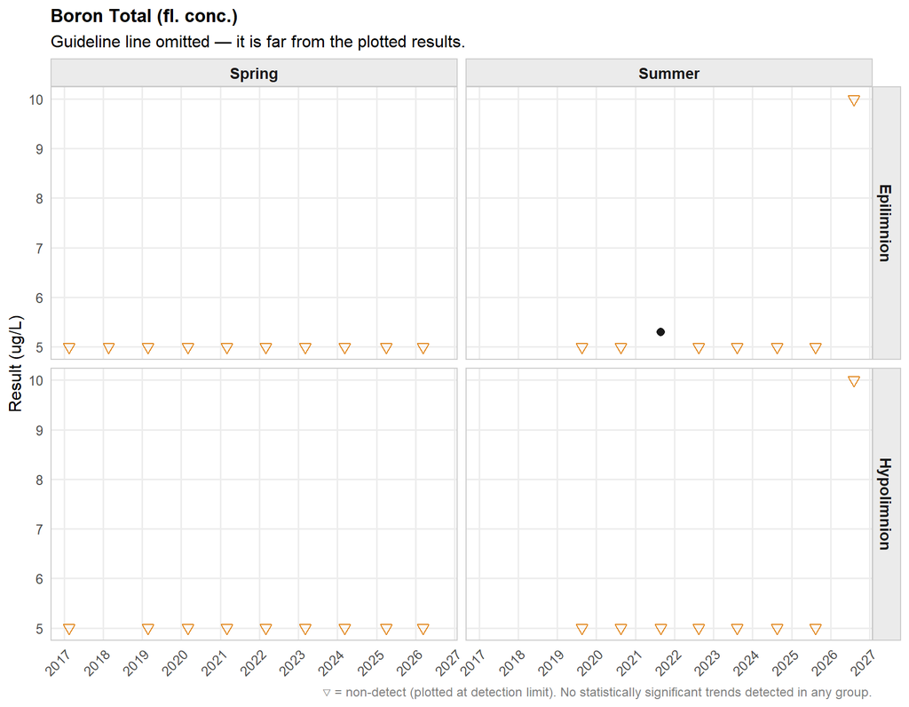

**▶ Summary Statistics Table**

**Lizard Lake**

Boron Total (fl. conc.) (ug/L)

| N | Min<sup>1</sup> | 10th %ile | Median | Mean | 90th %ile | Max |
| --- | --- | --- | --- | --- | --- | --- |
| Hypolimnion — Summer |  |  |  |  |  |  |
| 8 | <5 | <5 | <5 | 5.62 | 6.5 | 10 |
| Hypolimnion — Spring |  |  |  |  |  |  |
| 9 | <5 | <5 | <5 | <5 | <5 | <5 |
| Epilimnion — Summer |  |  |  |  |  |  |
| 8 | <5 | <5 | <5 | 5.66 | 6.71 | 10 |
| Epilimnion — Spring |  |  |  |  |  |  |
| 10 | <5 | <5 | <5 | <5 | <5 | <5 |

<sup>1</sup> < indicates non-detect; value shown is the detection limit.

##### Cadmium Total (fl. conc.)

—

No simple [BC Aquatic Life Guideline](https://www2.gov.bc.ca/gov/content?id=044DD64C7E24415D83D07430964113C9) available for this parameter

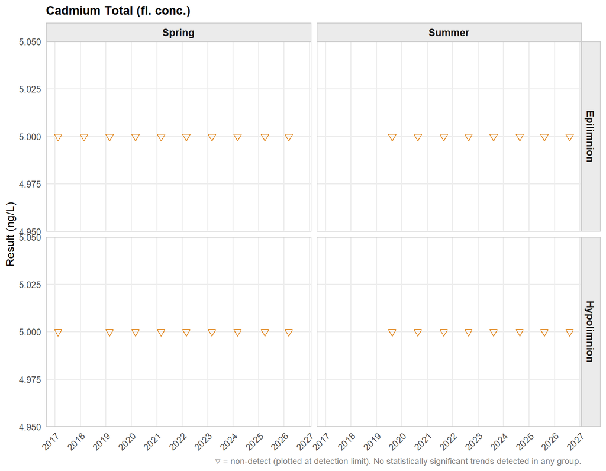

**▶ Summary Statistics Table**

**Lizard Lake**

Cadmium Total (fl. conc.) (ng/L)

| N | Min<sup>1</sup> | 10th %ile | Median | Mean | 90th %ile | Max |
| --- | --- | --- | --- | --- | --- | --- |
| Hypolimnion — Summer |  |  |  |  |  |  |
| 8 | <5 | <5 | <5 | <5 | <5 | <5 |
| Hypolimnion — Spring |  |  |  |  |  |  |
| 9 | <5 | <5 | <5 | <5 | <5 | <5 |
| Epilimnion — Summer |  |  |  |  |  |  |
| 8 | <5 | <5 | <5 | <5 | <5 | <5 |
| Epilimnion — Spring |  |  |  |  |  |  |
| 10 | <5 | <5 | <5 | <5 | <5 | <5 |

<sup>1</sup> < indicates non-detect; value shown is the detection limit.

##### Calcium Total (fl. conc.)

—

No simple [BC Aquatic Life Guideline](https://www2.gov.bc.ca/gov/content?id=044DD64C7E24415D83D07430964113C9) available for this parameter

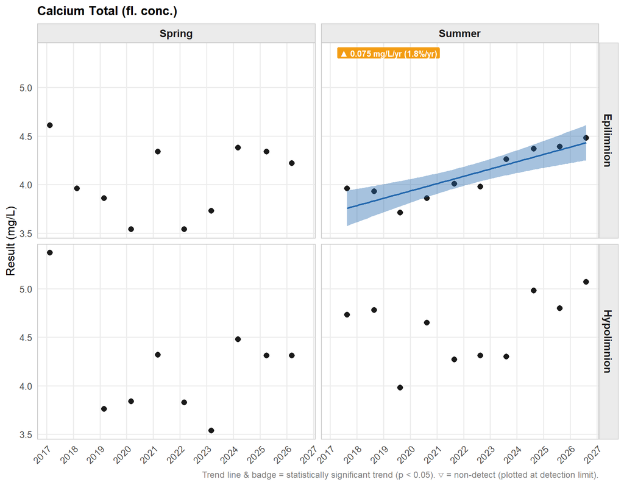

**▶ Summary Statistics Table**

**Lizard Lake**

Calcium Total (fl. conc.) (mg/L)

| N | Min<sup>1</sup> | 10th %ile | Median | Mean | 90th %ile | Max |
| --- | --- | --- | --- | --- | --- | --- |
| Hypolimnion — Summer |  |  |  |  |  |  |
| 10 | 3.98 | 4.24 | 4.69 | 4.59 | 4.99 | 5.07 |
| Hypolimnion — Spring |  |  |  |  |  |  |
| 9 | 3.54 | 3.72 | 4.31 | 4.2 | 4.66 | 5.37 |
| Epilimnion — Summer |  |  |  |  |  |  |
| 10 | 3.71 | 3.84 | 4 | 4.1 | 4.4 | 4.48 |
| Epilimnion — Spring |  |  |  |  |  |  |
| 10 | 3.54 | 3.54 | 4.09 | 4.05 | 4.4 | 4.61 |

<sup>1</sup> < indicates non-detect; value shown is the detection limit.

##### Chromium Total (fl. conc.)

—

No simple [BC Aquatic Life Guideline](https://www2.gov.bc.ca/gov/content?id=044DD64C7E24415D83D07430964113C9) available for this parameter

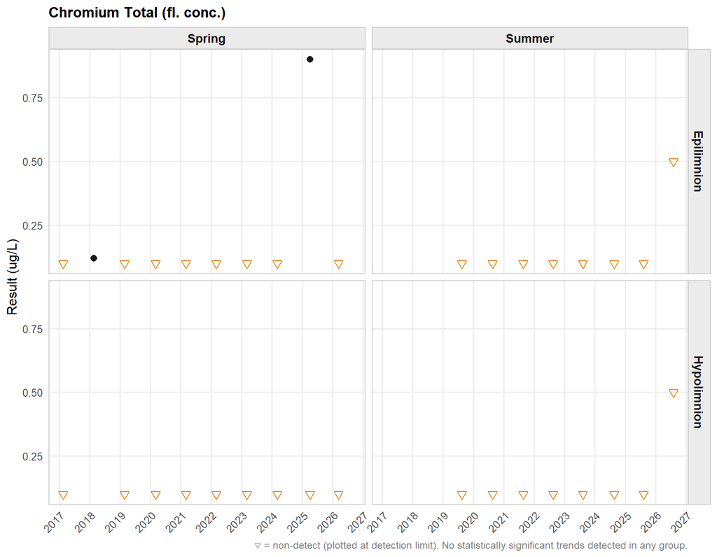

**▶ Summary Statistics Table**

**Lizard Lake**

Chromium Total (fl. conc.) (ug/L)

| N | Min<sup>1</sup> | 10th %ile | Median | Mean | 90th %ile | Max |
| --- | --- | --- | --- | --- | --- | --- |
| Hypolimnion — Summer |  |  |  |  |  |  |
| 8 | <0.1 | <0.1 | <0.1 | 0.15 | 0.22 | 0.5 |
| Hypolimnion — Spring |  |  |  |  |  |  |
| 9 | <0.1 | <0.1 | <0.1 | <0.1 | <0.1 | <0.1 |
| Epilimnion — Summer |  |  |  |  |  |  |
| 8 | <0.1 | <0.1 | <0.1 | 0.15 | 0.22 | 0.5 |
| Epilimnion — Spring |  |  |  |  |  |  |
| 10 | <0.1 | <0.1 | <0.1 | 0.182 | 0.198 | 0.9 |

<sup>1</sup> < indicates non-detect; value shown is the detection limit.

##### Cobalt Total (fl. conc.)

—

No simple [BC Aquatic Life Guideline](https://www2.gov.bc.ca/gov/content?id=044DD64C7E24415D83D07430964113C9) available for this parameter

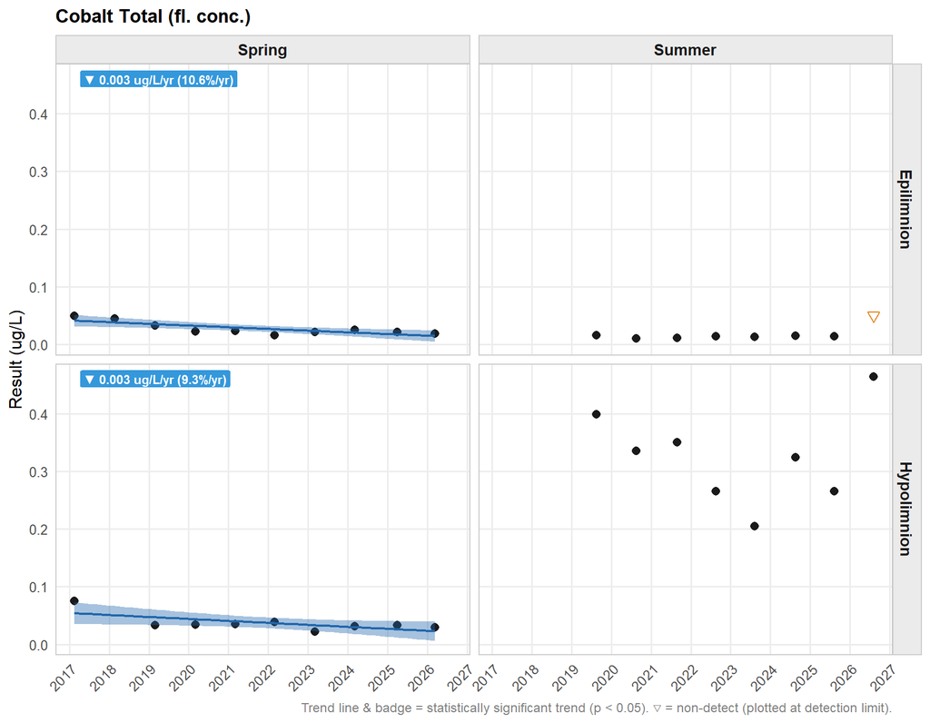

**▶ Summary Statistics Table**

**Lizard Lake**

Cobalt Total (fl. conc.) (ug/L)

| N | Min<sup>1</sup> | 10th %ile | Median | Mean | 90th %ile | Max |
| --- | --- | --- | --- | --- | --- | --- |
| Hypolimnion — Summer |  |  |  |  |  |  |
| 8 | 0.205 | 0.247 | 0.33 | 0.326 | 0.419 | 0.464 |
| Hypolimnion — Spring |  |  |  |  |  |  |
| 9 | <0.0215 | <0.0281 | <0.0331 | <0.0369 | <0.0462 | 0.0749 |
| Epilimnion — Summer |  |  |  |  |  |  |
| 8 | <0.0101 | <0.0109 | <0.0141 | <0.018 | <0.0263 | <0.05 |
| Epilimnion — Spring |  |  |  |  |  |  |
| 10 | <0.0159 | <0.0188 | <0.0232 | <0.0278 | <0.0456 | <0.0496 |

<sup>1</sup> < indicates non-detect; value shown is the detection limit.

##### Copper Total (fl. conc.)

—

No simple [BC Aquatic Life Guideline](https://www2.gov.bc.ca/gov/content?id=044DD64C7E24415D83D07430964113C9) available for this parameter

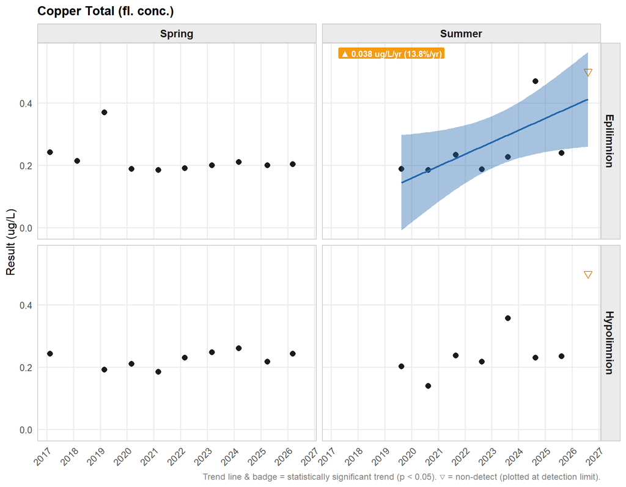

**▶ Summary Statistics Table**

**Lizard Lake**

Copper Total (fl. conc.) (ug/L)

| N | Min<sup>1</sup> | 10th %ile | Median | Mean | 90th %ile | Max |
| --- | --- | --- | --- | --- | --- | --- |
| Hypolimnion — Summer |  |  |  |  |  |  |
| 8 | <0.14 | <0.184 | <0.232 | <0.265 | <0.4 | <0.5 |
| Hypolimnion — Spring |  |  |  |  |  |  |
| 9 | <0.185 | <0.191 | <0.23 | <0.226 | <0.25 | <0.26 |
| Epilimnion — Summer |  |  |  |  |  |  |
| 8 | <0.184 | <0.186 | <0.229 | <0.278 | <0.478 | <0.5 |
| Epilimnion — Spring |  |  |  |  |  |  |
| 10 | <0.184 | <0.188 | <0.202 | <0.22 | <0.254 | <0.369 |

<sup>1</sup> < indicates non-detect; value shown is the detection limit.

##### Iron Total (fl. conc.)

—

No simple [BC Aquatic Life Guideline](https://www2.gov.bc.ca/gov/content?id=044DD64C7E24415D83D07430964113C9) available for this parameter

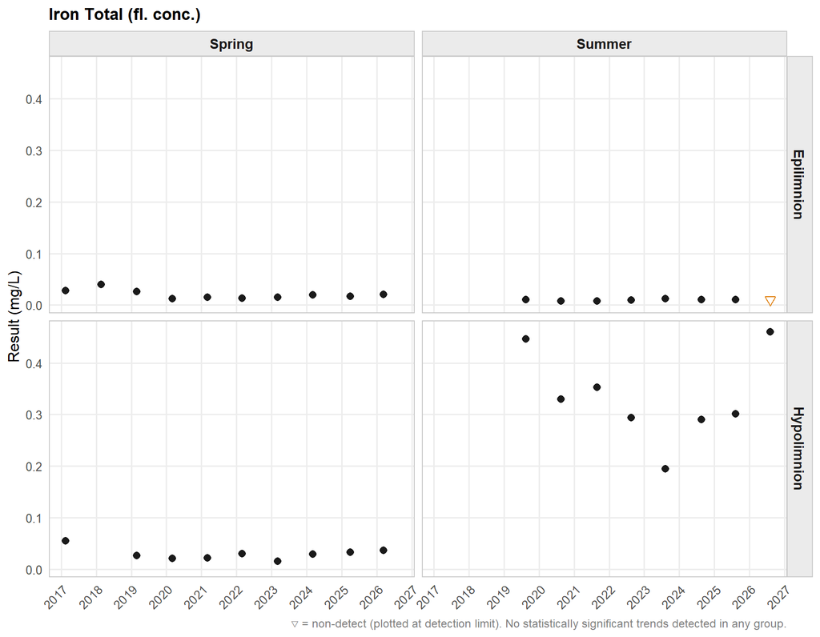

**▶ Summary Statistics Table**

**Lizard Lake**

Iron Total (fl. conc.) (mg/L)

| N | Min<sup>1</sup> | 10th %ile | Median | Mean | 90th %ile | Max |
| --- | --- | --- | --- | --- | --- | --- |
| Hypolimnion — Summer |  |  |  |  |  |  |
| 8 | 0.195 | 0.262 | 0.316 | 0.334 | 0.45 | 0.46 |
| Hypolimnion — Spring |  |  |  |  |  |  |
| 9 | 0.0152 | 0.0202 | 0.0292 | 0.0299 | 0.0403 | 0.0549 |
| Epilimnion — Summer |  |  |  |  |  |  |
| 8 | <0.0077 | <0.00798 | 0.0101 | <0.00994 | 0.0112 | 0.0125 |
| Epilimnion — Spring |  |  |  |  |  |  |
| 10 | 0.0122 | 0.0127 | 0.018 | 0.0205 | 0.0289 | 0.04 |

<sup>1</sup> < indicates non-detect; value shown is the detection limit.

##### Lead Total (fl. conc.)

—

No simple [BC Aquatic Life Guideline](https://www2.gov.bc.ca/gov/content?id=044DD64C7E24415D83D07430964113C9) available for this parameter

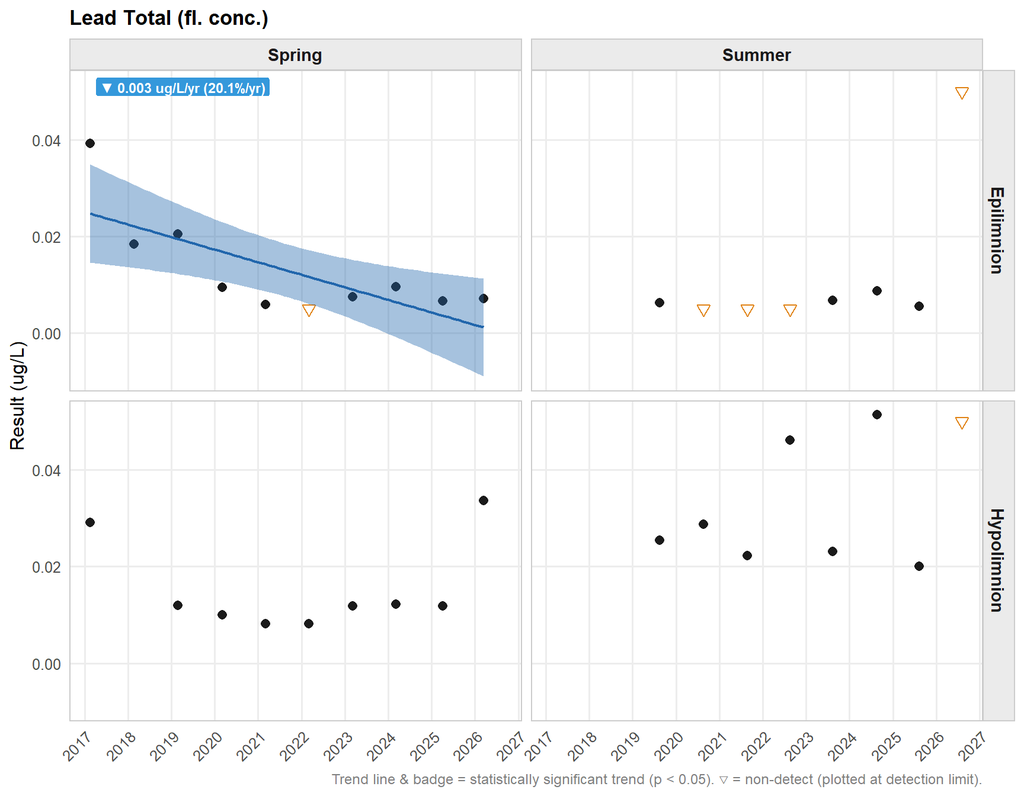

**▶ Summary Statistics Table**

**Lizard Lake**

Lead Total (fl. conc.) (ug/L)

| N | Min<sup>1</sup> | 10th %ile | Median | Mean | 90th %ile | Max |
| --- | --- | --- | --- | --- | --- | --- |
| Hypolimnion — Summer |  |  |  |  |  |  |
| 8 | 0.02 | 0.0215 | 0.027 | 0.0334 | 0.0504 | 0.0514 |
| Hypolimnion — Spring |  |  |  |  |  |  |
| 9 | 0.0082 | 0.0082 | 0.0118 | 0.0152 | 0.03 | 0.0336 |
| Epilimnion — Summer |  |  |  |  |  |  |
| 8 | <0.005 | <0.005 | 0.00585 | 0.0115 | 0.0211 | 0.05 |
| Epilimnion — Spring |  |  |  |  |  |  |
| 10 | <0.005 | 0.00581 | 0.00845 | 0.0129 | 0.0224 | 0.0392 |

<sup>1</sup> < indicates non-detect; value shown is the detection limit.

##### Lithium Total (fl. conc.)

—

No simple [BC Aquatic Life Guideline](https://www2.gov.bc.ca/gov/content?id=044DD64C7E24415D83D07430964113C9) available for this parameter

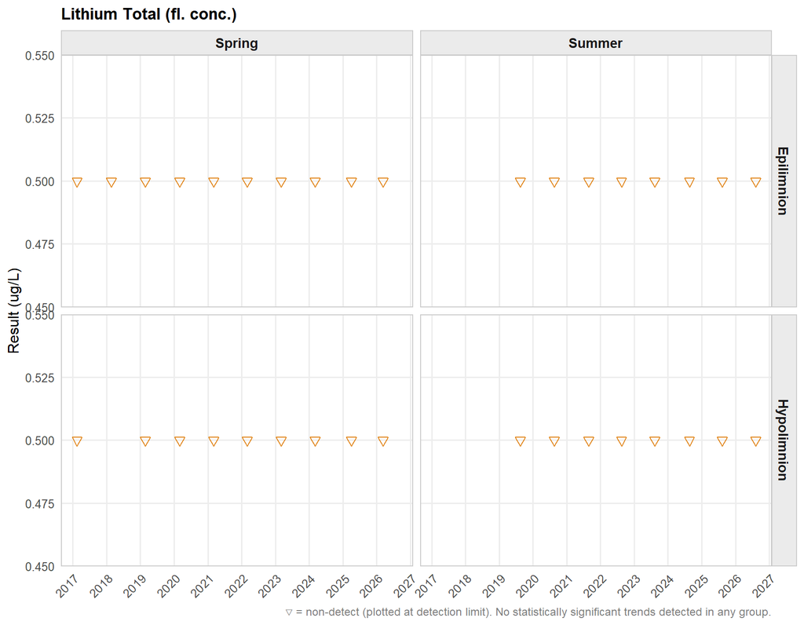

**▶ Summary Statistics Table**

**Lizard Lake**

Lithium Total (fl. conc.) (ug/L)

| N | Min<sup>1</sup> | 10th %ile | Median | Mean | 90th %ile | Max |
| --- | --- | --- | --- | --- | --- | --- |
| Hypolimnion — Summer |  |  |  |  |  |  |
| 8 | <0.5 | <0.5 | <0.5 | <0.5 | <0.5 | <0.5 |
| Hypolimnion — Spring |  |  |  |  |  |  |
| 9 | <0.5 | <0.5 | <0.5 | <0.5 | <0.5 | <0.5 |
| Epilimnion — Summer |  |  |  |  |  |  |
| 8 | <0.5 | <0.5 | <0.5 | <0.5 | <0.5 | <0.5 |
| Epilimnion — Spring |  |  |  |  |  |  |
| 10 | <0.5 | <0.5 | <0.5 | <0.5 | <0.5 | <0.5 |

<sup>1</sup> < indicates non-detect; value shown is the detection limit.

##### Magnesium Total (fl. conc.)

—

No simple [BC Aquatic Life Guideline](https://www2.gov.bc.ca/gov/content?id=044DD64C7E24415D83D07430964113C9) available for this parameter

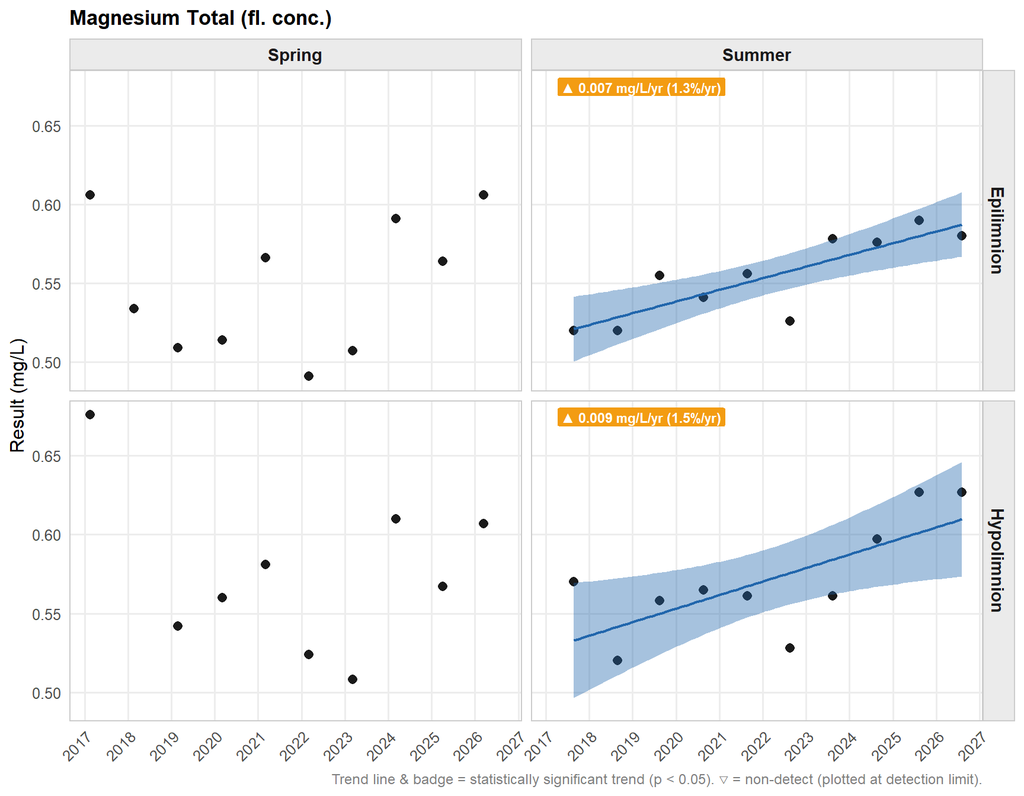

**▶ Summary Statistics Table**

**Lizard Lake**

Magnesium Total (fl. conc.) (mg/L)

| N | Min<sup>1</sup> | 10th %ile | Median | Mean | 90th %ile | Max |
| --- | --- | --- | --- | --- | --- | --- |
| Hypolimnion — Summer |  |  |  |  |  |  |
| 10 | 0.52 | 0.527 | 0.563 | 0.571 | 0.627 | 0.627 |
| Hypolimnion — Spring |  |  |  |  |  |  |
| 9 | 0.508 | 0.521 | 0.567 | 0.575 | 0.623 | 0.676 |
| Epilimnion — Summer |  |  |  |  |  |  |
| 10 | 0.52 | 0.52 | 0.556 | 0.554 | 0.581 | 0.59 |
| Epilimnion — Spring |  |  |  |  |  |  |
| 10 | 0.491 | 0.505 | 0.549 | 0.549 | 0.606 | 0.606 |

<sup>1</sup> < indicates non-detect; value shown is the detection limit.

##### Manganese Total (fl. conc.)

—

No simple [BC Aquatic Life Guideline](https://www2.gov.bc.ca/gov/content?id=044DD64C7E24415D83D07430964113C9) available for this parameter

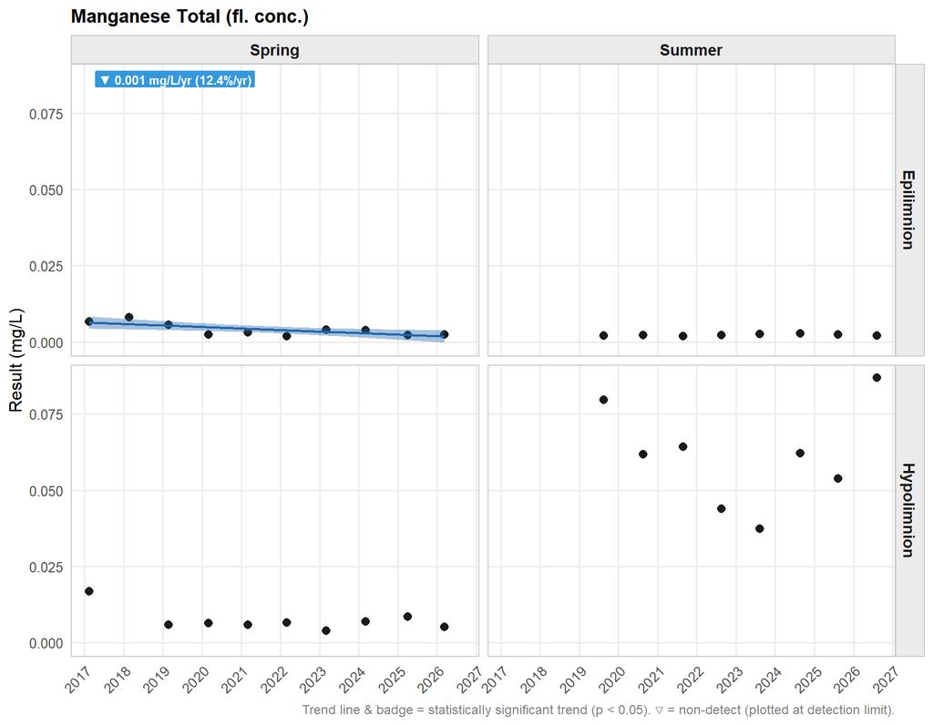

**▶ Summary Statistics Table**

**Lizard Lake**

Manganese Total (fl. conc.) (mg/L)

| N | Min<sup>1</sup> | 10th %ile | Median | Mean | 90th %ile | Max |
| --- | --- | --- | --- | --- | --- | --- |
| Hypolimnion — Summer |  |  |  |  |  |  |
| 8 | 0.0373 | 0.0419 | 0.062 | 0.0612 | 0.0819 | 0.0869 |
| Hypolimnion — Spring |  |  |  |  |  |  |
| 9 | 0.00391 | 0.00485 | 0.00639 | 0.00734 | 0.0102 | 0.0169 |
| Epilimnion — Summer |  |  |  |  |  |  |
| 8 | 0.00189 | 0.00199 | 0.00225 | 0.00228 | 0.00264 | 0.00269 |
| Epilimnion — Spring |  |  |  |  |  |  |
| 10 | 0.00197 | 0.00223 | 0.00351 | 0.00404 | 0.00683 | 0.00802 |

<sup>1</sup> < indicates non-detect; value shown is the detection limit.

##### Molybdenum Total (fl. conc.)

✓

[BC Aquatic Life Guideline](https://www2.gov.bc.ca/gov/content/environment/air-land-water/water/water-quality/water-quality-guidelines/approved-water-quality-guidelines) · Long-term chronic (Upper Limit) Aquatic Life - Freshwater

≤7600 ug/L

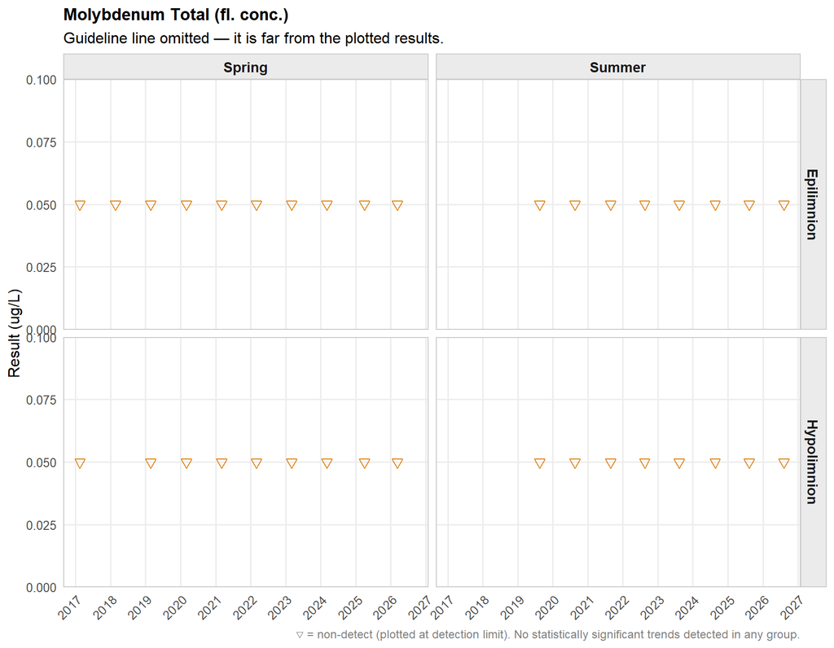

**▶ Summary Statistics Table**

**Lizard Lake**

Molybdenum Total (fl. conc.) (ug/L)

| N | Min<sup>1</sup> | 10th %ile | Median | Mean | 90th %ile | Max |
| --- | --- | --- | --- | --- | --- | --- |
| Hypolimnion — Summer |  |  |  |  |  |  |
| 8 | <0.05 | <0.05 | <0.05 | <0.05 | <0.05 | <0.05 |
| Hypolimnion — Spring |  |  |  |  |  |  |
| 9 | <0.05 | <0.05 | <0.05 | <0.05 | <0.05 | <0.05 |
| Epilimnion — Summer |  |  |  |  |  |  |
| 8 | <0.05 | <0.05 | <0.05 | <0.05 | <0.05 | <0.05 |
| Epilimnion — Spring |  |  |  |  |  |  |
| 10 | <0.05 | <0.05 | <0.05 | <0.05 | <0.05 | <0.05 |

<sup>1</sup> < indicates non-detect; value shown is the detection limit.

##### Nickel Total (fl. conc.)

—

No simple [BC Aquatic Life Guideline](https://www2.gov.bc.ca/gov/content?id=044DD64C7E24415D83D07430964113C9) available for this parameter

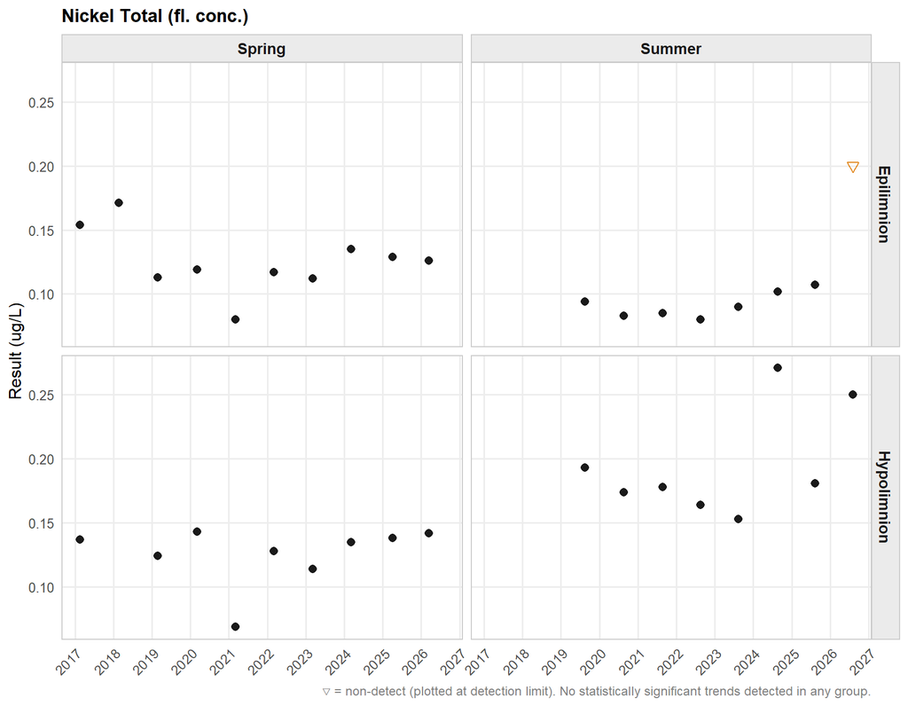

**▶ Summary Statistics Table**

**Lizard Lake**

Nickel Total (fl. conc.) (ug/L)

| N | Min<sup>1</sup> | 10th %ile | Median | Mean | 90th %ile | Max |
| --- | --- | --- | --- | --- | --- | --- |
| Hypolimnion — Summer |  |  |  |  |  |  |
| 8 | <0.153 | <0.161 | <0.18 | <0.196 | 0.256 | 0.271 |
| Hypolimnion — Spring |  |  |  |  |  |  |
| 9 | <0.069 | <0.105 | <0.135 | <0.126 | <0.142 | <0.143 |
| Epilimnion — Summer |  |  |  |  |  |  |
| 8 | <0.08 | <0.0821 | <0.092 | <0.105 | <0.135 | <0.2 |
| Epilimnion — Spring |  |  |  |  |  |  |
| 10 | <0.08 | <0.109 | <0.122 | <0.126 | <0.156 | <0.171 |

<sup>1</sup> < indicates non-detect; value shown is the detection limit.

##### Potassium Total (fl. conc.)

—

No simple [BC Aquatic Life Guideline](https://www2.gov.bc.ca/gov/content?id=044DD64C7E24415D83D07430964113C9) available for this parameter

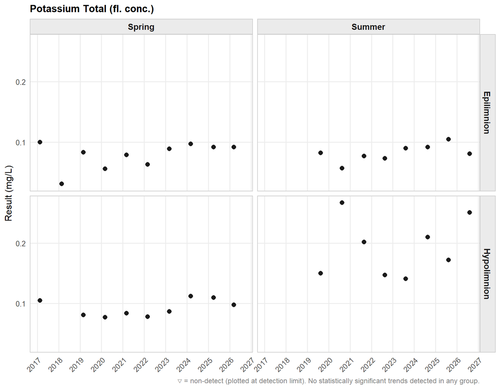

**▶ Summary Statistics Table**

**Lizard Lake**

Potassium Total (fl. conc.) (mg/L)

| N | Min<sup>1</sup> | 10th %ile | Median | Mean | 90th %ile | Max |
| --- | --- | --- | --- | --- | --- | --- |
| Hypolimnion — Summer |  |  |  |  |  |  |
| 8 | 0.141 | 0.145 | 0.187 | 0.192 | 0.256 | 0.267 |
| Hypolimnion — Spring |  |  |  |  |  |  |
| 9 | 0.077 | 0.0778 | 0.087 | 0.0924 | 0.11 | 0.112 |
| Epilimnion — Summer |  |  |  |  |  |  |
| 8 | 0.057 | 0.0682 | 0.0815 | 0.0821 | 0.0959 | 0.105 |
| Epilimnion — Spring |  |  |  |  |  |  |
| 10 | 0.0309 | 0.0535 | 0.0862 | 0.0782 | 0.0973 | 0.1 |

<sup>1</sup> < indicates non-detect; value shown is the detection limit.

##### Selenium Total (fl. conc.)

✓

[BC Aquatic Life Guideline](https://www2.gov.bc.ca/gov/content/environment/air-land-water/water/water-quality/water-quality-guidelines/approved-water-quality-guidelines) · Long-term chronic (Upper Limit) Aquatic Life - Freshwater

≤2 ug/L

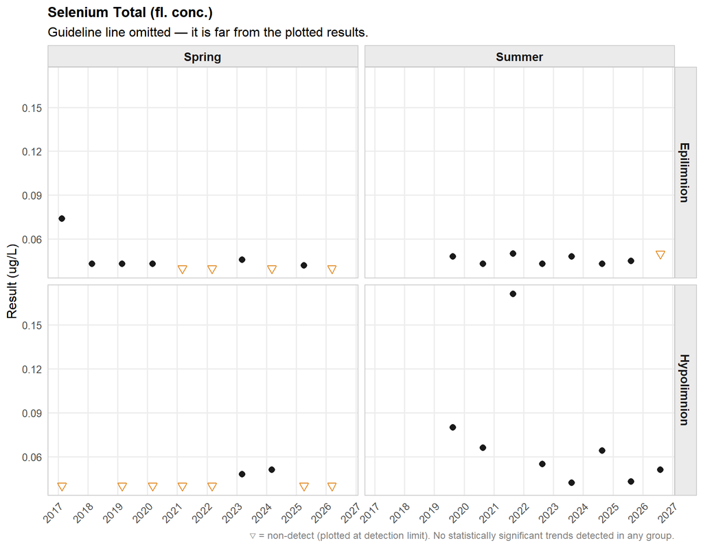

**▶ Summary Statistics Table**

**Lizard Lake**

Selenium Total (fl. conc.) (ug/L)

| N | Min<sup>1</sup> | 10th %ile | Median | Mean | 90th %ile | Max |
| --- | --- | --- | --- | --- | --- | --- |
| Hypolimnion — Summer |  |  |  |  |  |  |
| 8 | 0.042 | 0.0427 | 0.0595 | 0.0715 | 0.107 | 0.171 |
| Hypolimnion — Spring |  |  |  |  |  |  |
| 9 | <0.04 | <0.04 | <0.04 | 0.0421 | 0.0486 | 0.051 |
| Epilimnion — Summer |  |  |  |  |  |  |
| 8 | 0.043 | 0.043 | 0.0465 | 0.0462 | 0.05 | 0.05 |
| Epilimnion — Spring |  |  |  |  |  |  |
| 10 | <0.04 | <0.04 | 0.0425 | 0.0451 | 0.0488 | 0.074 |

<sup>1</sup> < indicates non-detect; value shown is the detection limit.

##### Silicon Total (fl. conc.)

—

No simple [BC Aquatic Life Guideline](https://www2.gov.bc.ca/gov/content?id=044DD64C7E24415D83D07430964113C9) available for this parameter

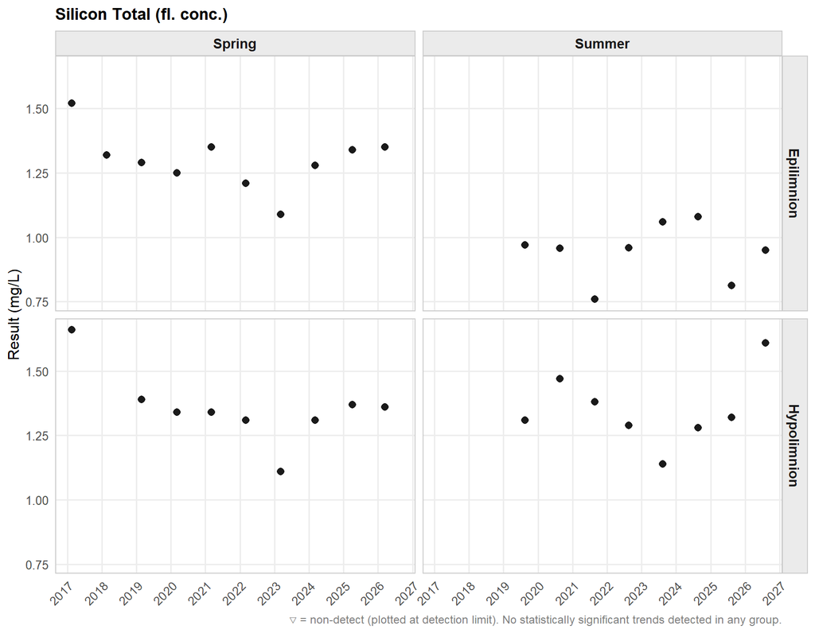

**▶ Summary Statistics Table**

**Lizard Lake**

Silicon Total (fl. conc.) (mg/L)

| N | Min<sup>1</sup> | 10th %ile | Median | Mean | 90th %ile | Max |
| --- | --- | --- | --- | --- | --- | --- |
| Hypolimnion — Summer |  |  |  |  |  |  |
| 8 | 1.14 | 1.24 | 1.32 | 1.35 | 1.51 | 1.61 |
| Hypolimnion — Spring |  |  |  |  |  |  |
| 9 | 1.11 | 1.27 | 1.34 | 1.35 | 1.44 | 1.66 |
| Epilimnion — Summer |  |  |  |  |  |  |
| 8 | 0.76 | 0.797 | 0.958 | 0.944 | 1.07 | 1.08 |
| Epilimnion — Spring |  |  |  |  |  |  |
| 10 | 1.09 | 1.2 | 1.31 | 1.3 | 1.37 | 1.52 |

<sup>1</sup> < indicates non-detect; value shown is the detection limit.

##### Silver Total (fl. conc.)

✓

[BC Aquatic Life Guideline](https://www2.gov.bc.ca/gov/content/environment/air-land-water/water/water-quality/water-quality-guidelines/approved-water-quality-guidelines) · Long-term chronic (Upper Limit) Aquatic Life - Freshwater

≤120 ng/L

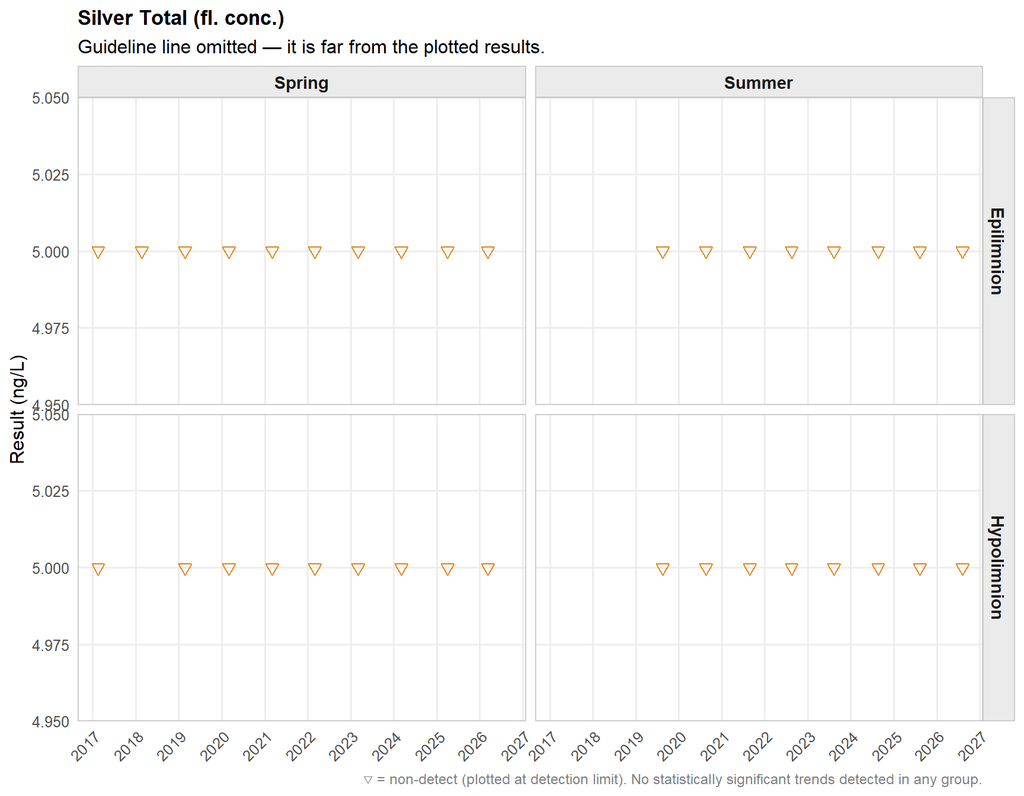

**▶ Summary Statistics Table**

**Lizard Lake**

Silver Total (fl. conc.) (ng/L)

| N | Min<sup>1</sup> | 10th %ile | Median | Mean | 90th %ile | Max |
| --- | --- | --- | --- | --- | --- | --- |
| Hypolimnion — Summer |  |  |  |  |  |  |
| 8 | <5 | <5 | <5 | <5 | <5 | <5 |
| Hypolimnion — Spring |  |  |  |  |  |  |
| 9 | <5 | <5 | <5 | <5 | <5 | <5 |
| Epilimnion — Summer |  |  |  |  |  |  |
| 8 | <5 | <5 | <5 | <5 | <5 | <5 |
| Epilimnion — Spring |  |  |  |  |  |  |
| 10 | <5 | <5 | <5 | <5 | <5 | <5 |

<sup>1</sup> < indicates non-detect; value shown is the detection limit.

##### Sodium Total (fl. conc.)

—

No simple [BC Aquatic Life Guideline](https://www2.gov.bc.ca/gov/content?id=044DD64C7E24415D83D07430964113C9) available for this parameter

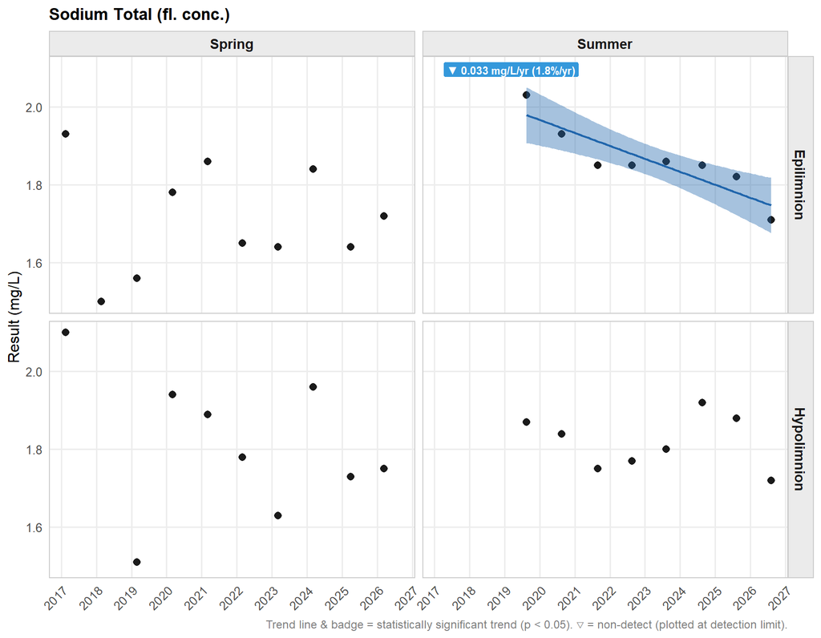

**▶ Summary Statistics Table**

**Lizard Lake**

Sodium Total (fl. conc.) (mg/L)

| N | Min<sup>1</sup> | 10th %ile | Median | Mean | 90th %ile | Max |
| --- | --- | --- | --- | --- | --- | --- |
| Hypolimnion — Summer |  |  |  |  |  |  |
| 8 | 1.72 | 1.74 | 1.82 | 1.82 | 1.89 | 1.92 |
| Hypolimnion — Spring |  |  |  |  |  |  |
| 9 | 1.51 | 1.61 | 1.78 | 1.81 | 1.99 | 2.1 |
| Epilimnion — Summer |  |  |  |  |  |  |
| 8 | 1.71 | 1.79 | 1.85 | 1.86 | 1.96 | 2.03 |
| Epilimnion — Spring |  |  |  |  |  |  |
| 10 | 1.5 | 1.55 | 1.68 | 1.71 | 1.87 | 1.93 |

<sup>1</sup> < indicates non-detect; value shown is the detection limit.

##### Strontium Total (fl. conc.)

—

No simple [BC Aquatic Life Guideline](https://www2.gov.bc.ca/gov/content?id=044DD64C7E24415D83D07430964113C9) available for this parameter

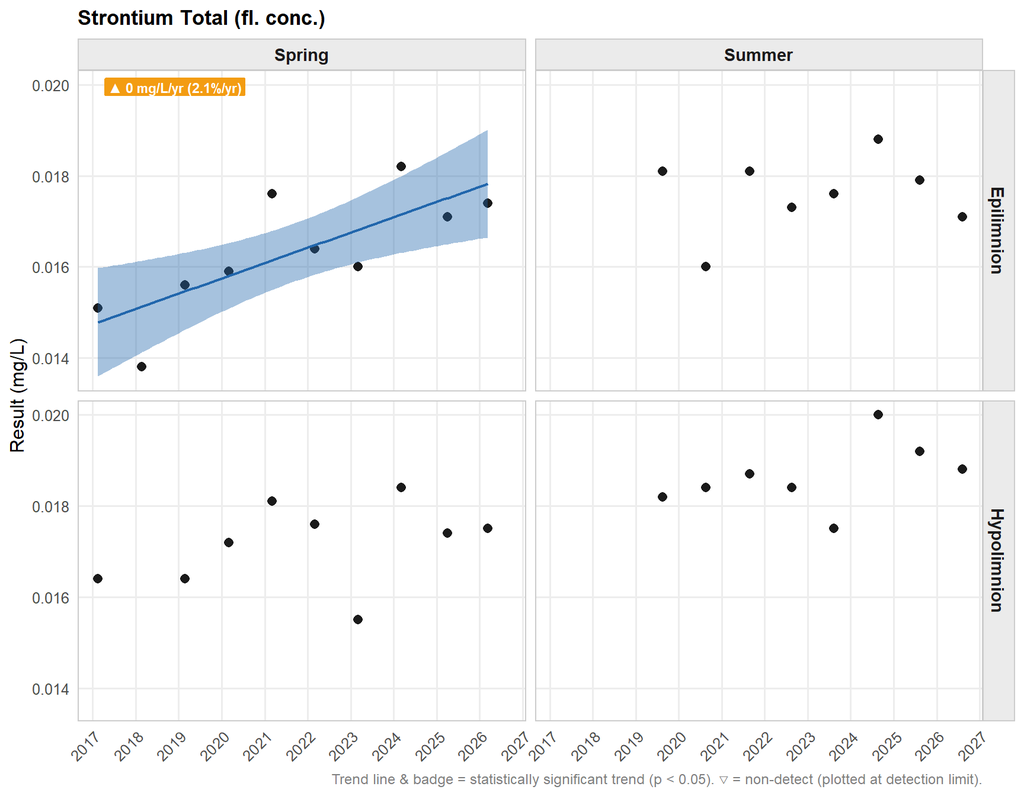

**▶ Summary Statistics Table**

**Lizard Lake**

Strontium Total (fl. conc.) (mg/L)

| N | Min<sup>1</sup> | 10th %ile | Median | Mean | 90th %ile | Max |
| --- | --- | --- | --- | --- | --- | --- |
| Hypolimnion — Summer |  |  |  |  |  |  |
| 8 | 0.0175 | 0.018 | 0.0186 | 0.0186 | 0.0194 | 0.02 |
| Hypolimnion — Spring |  |  |  |  |  |  |
| 9 | 0.0155 | 0.0162 | 0.0174 | 0.0172 | 0.0182 | 0.0184 |
| Epilimnion — Summer |  |  |  |  |  |  |
| 8 | 0.016 | 0.0168 | 0.0178 | 0.0176 | 0.0183 | 0.0188 |
| Epilimnion — Spring |  |  |  |  |  |  |
| 10 | 0.0138 | 0.015 | 0.0162 | 0.0163 | 0.0177 | 0.0182 |

<sup>1</sup> < indicates non-detect; value shown is the detection limit.

##### Thallium Total (fl. conc.)

✓

[BC Aquatic Life Guideline](https://www2.gov.bc.ca/gov/content/environment/air-land-water/water/water-quality/water-quality-guidelines/approved-water-quality-guidelines) · Long-term chronic (Upper Limit) Aquatic Life - Freshwater

≤30 ng/L

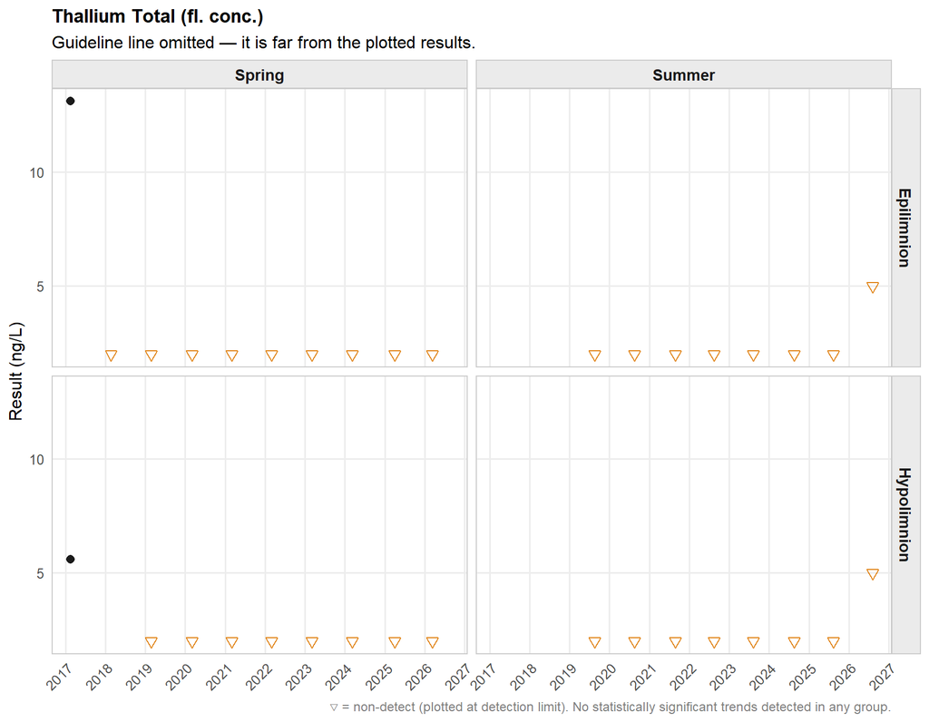

**▶ Summary Statistics Table**

**Lizard Lake**

Thallium Total (fl. conc.) (ng/L)

| N | Min<sup>1</sup> | 10th %ile | Median | Mean | 90th %ile | Max |
| --- | --- | --- | --- | --- | --- | --- |
| Hypolimnion — Summer |  |  |  |  |  |  |
| 8 | <2 | <2 | <2 | 2.38 | 2.9 | 5 |
| Hypolimnion — Spring |  |  |  |  |  |  |
| 9 | <2 | <2 | <2 | 2.4 | 2.72 | 5.6 |
| Epilimnion — Summer |  |  |  |  |  |  |
| 8 | <2 | <2 | <2 | 2.38 | 2.9 | 5 |
| Epilimnion — Spring |  |  |  |  |  |  |
| 10 | <2 | <2 | <2 | 3.11 | 3.11 | 13.1 |

<sup>1</sup> < indicates non-detect; value shown is the detection limit.

##### Tin Total (fl. conc.)

—

No simple [BC Aquatic Life Guideline](https://www2.gov.bc.ca/gov/content?id=044DD64C7E24415D83D07430964113C9) available for this parameter

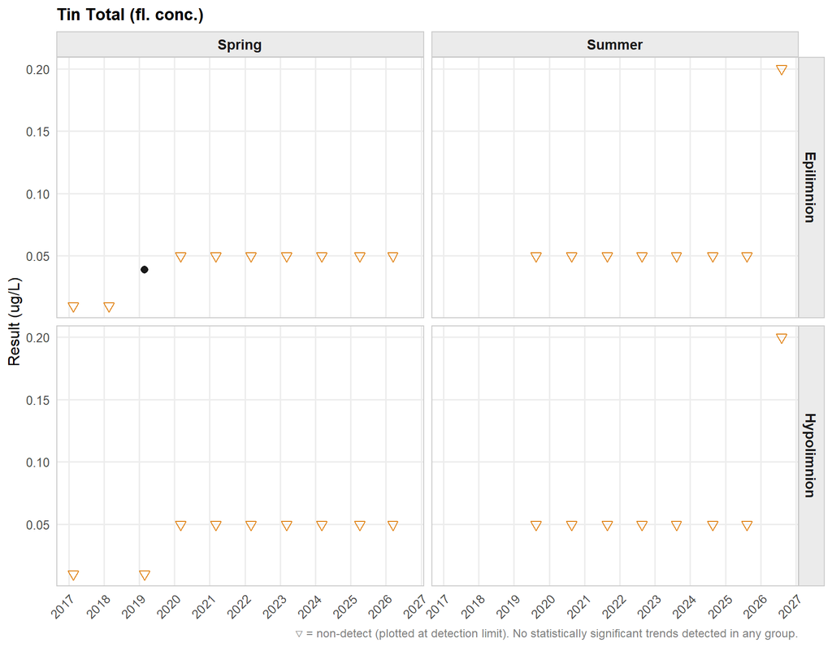

**▶ Summary Statistics Table**

**Lizard Lake**

Tin Total (fl. conc.) (ug/L)

| N | Min<sup>1</sup> | 10th %ile | Median | Mean | 90th %ile | Max |
| --- | --- | --- | --- | --- | --- | --- |
| Hypolimnion — Summer |  |  |  |  |  |  |
| 8 | 0.05 | 0.05 | 0.05 | 0.0688 | 0.095 | 0.2 |
| Hypolimnion — Spring |  |  |  |  |  |  |
| 9 | <0.01 | <0.01 | 0.05 | 0.0411 | 0.05 | 0.05 |
| Epilimnion — Summer |  |  |  |  |  |  |
| 8 | 0.05 | 0.05 | 0.05 | 0.0688 | 0.095 | 0.2 |
| Epilimnion — Spring |  |  |  |  |  |  |
| 10 | <0.01 | <0.01 | 0.05 | 0.0409 | 0.05 | 0.05 |

<sup>1</sup> < indicates non-detect; value shown is the detection limit.

##### Uranium Total (fl. conc.)

✓

[BC Aquatic Life Guideline](https://www2.gov.bc.ca/gov/content/environment/air-land-water/water/water-quality/water-quality-guidelines/approved-water-quality-guidelines) · Long-term chronic (Upper Limit) Aquatic Life - Freshwater

≤7500 ng/L

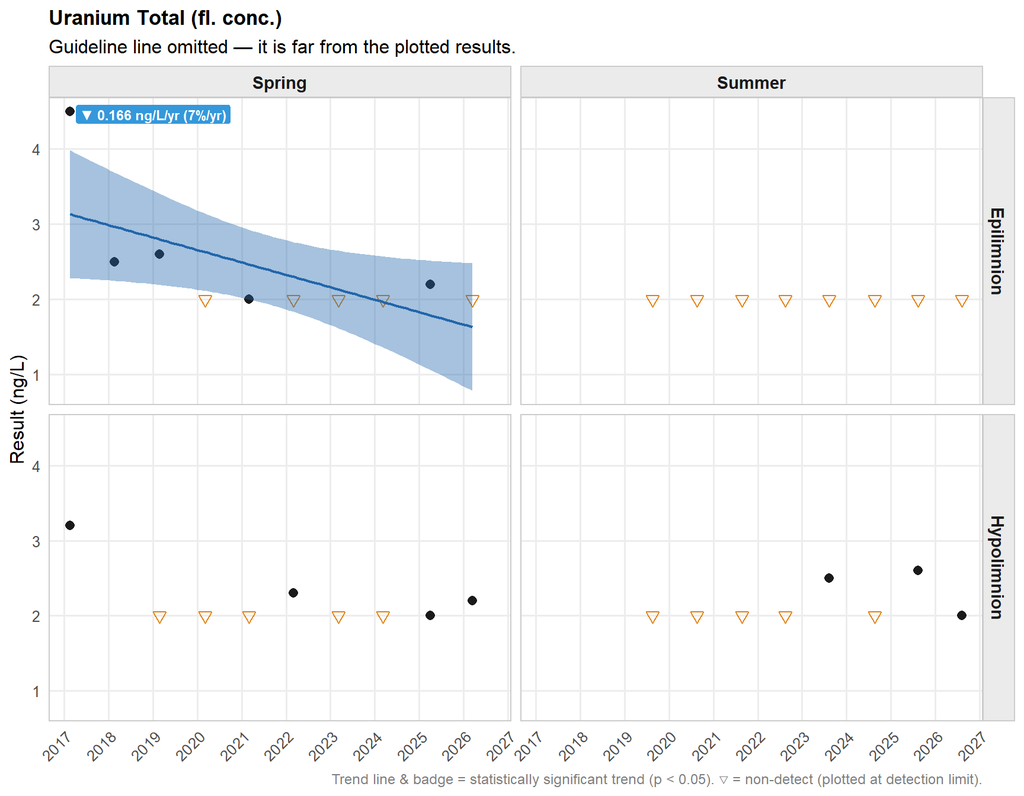

**▶ Summary Statistics Table**

**Lizard Lake**

Uranium Total (fl. conc.) (ng/L)

| N | Min<sup>1</sup> | 10th %ile | Median | Mean | 90th %ile | Max |
| --- | --- | --- | --- | --- | --- | --- |
| Hypolimnion — Summer |  |  |  |  |  |  |
| 8 | <2 | <2 | <2 | 2.14 | 2.53 | 2.6 |
| Hypolimnion — Spring |  |  |  |  |  |  |
| 9 | <2 | <2 | <2 | 2.19 | 2.48 | 3.2 |
| Epilimnion — Summer |  |  |  |  |  |  |
| 8 | <2 | <2 | <2 | <2 | <2 | <2 |
| Epilimnion — Spring |  |  |  |  |  |  |
| 10 | <2 | <2 | <2 | 2.38 | 2.79 | 4.5 |

<sup>1</sup> < indicates non-detect; value shown is the detection limit.

##### Vanadium Total (fl. conc.)

✓

[BC Aquatic Life Guideline](https://www2.gov.bc.ca/gov/content/environment/air-land-water/water/water-quality/water-quality-guidelines/approved-water-quality-guidelines) · Long-term chronic (Upper Limit) Aquatic Life - Freshwater

≤60 ug/L

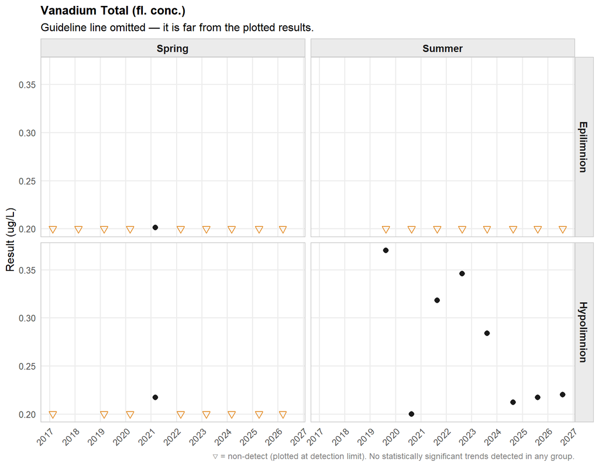

**▶ Summary Statistics Table**

**Lizard Lake**

Vanadium Total (fl. conc.) (ug/L)

| N | Min<sup>1</sup> | 10th %ile | Median | Mean | 90th %ile | Max |
| --- | --- | --- | --- | --- | --- | --- |
| Hypolimnion — Summer |  |  |  |  |  |  |
| 8 | <0.2 | 0.208 | 0.252 | 0.271 | 0.353 | 0.37 |
| Hypolimnion — Spring |  |  |  |  |  |  |
| 9 | <0.2 | <0.2 | <0.2 | 0.202 | 0.203 | 0.217 |
| Epilimnion — Summer |  |  |  |  |  |  |
| 8 | <0.2 | <0.2 | <0.2 | <0.2 | <0.2 | <0.2 |
| Epilimnion — Spring |  |  |  |  |  |  |
| 10 | <0.2 | <0.2 | <0.2 | <0.2 | <0.2 | 0.201 |

<sup>1</sup> < indicates non-detect; value shown is the detection limit.

##### Zinc Total (fl. conc.)

—

No simple [BC Aquatic Life Guideline](https://www2.gov.bc.ca/gov/content?id=044DD64C7E24415D83D07430964113C9) available for this parameter

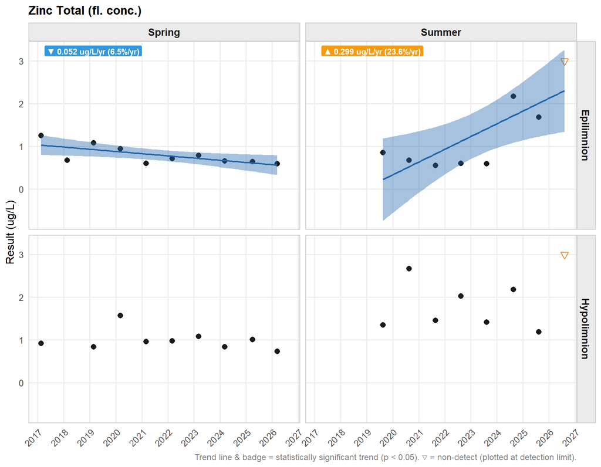

**▶ Summary Statistics Table**

**Lizard Lake**

Zinc Total (fl. conc.) (ug/L)

| N | Min<sup>1</sup> | 10th %ile | Median | Mean | 90th %ile | Max |
| --- | --- | --- | --- | --- | --- | --- |
| Hypolimnion — Summer |  |  |  |  |  |  |
| 8 | <1.19 | <1.3 | <1.74 | <1.91 | <2.77 | <3 |
| Hypolimnion — Spring |  |  |  |  |  |  |
| 9 | <0.73 | <0.818 | <0.96 | <0.992 | <1.18 | <1.57 |
| Epilimnion — Summer |  |  |  |  |  |  |
| 8 | <0.55 | <0.578 | <0.76 | <1.26 | <2.42 | <3 |
| Epilimnion — Spring |  |  |  |  |  |  |
| 10 | <0.59 | <0.599 | <0.69 | <0.793 | <1.1 | <1.25 |

<sup>1</sup> < indicates non-detect; value shown is the detection limit.

### Disclaimer

This document was produced by an automated system and has not necessarily gone through quality control checks. It is presented “as-is” with no guarantee of accuracy or completeness. Read our full [Disclaimer](https://www2.gov.bc.ca/gov/content?id=79F93E018712422FBC8E674A67A70535) for more information.